# EDA on Flight prices across the major cities of India.

Routes we will be analyzing are: Mumbai(BOM) ↔️ Bengaluru(BLR) Delhi(DEL) ↔️ Bengaluru(BLR) Delhi(DEL) ↔️ Mumbai(BOM) Delhi(DEL) ↔️ Kolkata(CCU) Delhi(DEL) ↔️ Hyderabad (HYD)

```python
import pandas as pd
import numpy as np
import matplotlib.pyplot as plt
import matplotlib
import seaborn as sns
%matplotlib inline
```

```python
import os
os.getcwd()
```

```
'C:\\Users\\Laptop\\Python_ivy_cls\\Spotify_songs'
```

```python
df_1 = pd.read_csv(r'C:\\Users\\Laptop\\Python_ivy_cls\\Flight Data\\flight_data_BOM_BLR.csv' , encoding = 'Unicode escape')
df_2 = pd.read_csv(r'C:\\Users\\Laptop\\Python_ivy_cls\\Flight Data\\flight_data_DEL_BLR.csv' , encoding = 'Unicode escape')
df_3 = pd.read_csv(r'C:\\Users\\Laptop\\Python_ivy_cls\\Flight Data\\flight_data_DEL_BOM.csv' , encoding = 'Unicode escape')
df_4 = pd.read_csv(r'C:\\Users\\Laptop\\Python_ivy_cls\\Flight Data\\flight_data_DEL_CCU.csv' , encoding = 'Unicode escape')
df_5 = pd.read_csv(r'C:\\Users\\Laptop\\Python_ivy_cls\\Flight Data\\flight_data_DEL_HYD.csv' , encoding = 'Unicode escape')
```

# Data Preprocessing

```python
df_1.head()
```

|  | FlightName | FlightCode | DepartingCity | DepartingTime | ArrivingCity | ArrivingTime | Duration | Price |
| --- | --- | --- | --- | --- | --- | --- | --- | --- |
| 0 | Air India | AI 621 | Mumbai | 03:55 | Bengaluru | 05:50 | 01 h 55 m | 2,307 |
| 1 | AirAsia | I5 670 | Mumbai | 19:55 | Bengaluru | 21:45 | 01 h 50 m | 2,773 |
| 2 | AirAsia | I5 2992 | Mumbai | 23:55 | Bengaluru | 01:45\r\n+ 1 DAY | 01 h 50 m | 2,773 |
| 3 | IndiGo | 6E 5388 | Mumbai | 21:30 | Bengaluru | 23:15 | 01 h 45 m | 2,839 |
| 4 | Akasa Air | QP 1103 | Mumbai | 00:45 | Bengaluru | 02:20 | 01 h 35 m | 3,005 |

```python
df_2.head()
```

|  | FlightName | FlightCode | DepartingCity | DepartingTime | ArrivingCity | ArrivingTime | Duration | Price |
| --- | --- | --- | --- | --- | --- | --- | --- | --- |
| 0 | Akasa Air | QP 1409 | New Delhi | 23:00 | Bengaluru | 01:45\n+ 1 DAY | 02 h 45 m | 5,230 |
| 1 | AirAsia | I5 740 | New Delhi | 07:50 | Bengaluru | 10:40 | 02 h 50 m | 5,235 |
| 2 | AirAsia | I5 1534 | New Delhi | 22:55 | Bengaluru | 01:35\n+ 1 DAY | 02 h 40 m | 5,235 |
| 3 | IndiGo | 6E 2067 | New Delhi | 03:55 | Bengaluru | 06:45 | 02 h 50 m | 5,236 |
| 4 | IndiGo | 6E 6612 | New Delhi | 05:50 | Bengaluru | 08:35 | 02 h 45 m | 5,236 |

```python
df_3.head()
```

|  | FlightName | FlightCode | DepartingCity | DepartingTime | ArrivingCity | ArrivingTime | Duration | Price |
| --- | --- | --- | --- | --- | --- | --- | --- | --- |
| 0 | Akasa Air | QP 1719 | New Delhi | 09:00 | Mumbai | 10:55 | 01 h 55 m | 4,758 |
| 1 | Akasa Air | QP 1411 | New Delhi | 10:55 | Mumbai | 13:05 | 02 h 10 m | 4,758 |
| 2 | Akasa Air | QP 1128 | New Delhi | 16:00 | Mumbai | 18:10 | 02 h 10 m | 4,758 |
| 3 | IndiGo | 6E 2009 | New Delhi | 01:00 | Mumbai | 03:00 | 02 h | 4,780 |
| 4 | IndiGo | 6E 2112 | New Delhi | 05:30 | Mumbai | 07:35 | 02 h 05 m | 4,780 |

```python
df_4.head()
```

|  | FlightName | FlightCode | DepartingCity | DepartingTime | ArrivingCity | ArrivingTime | Duration | Price |
| --- | --- | --- | --- | --- | --- | --- | --- | --- |
| 0 | IndiGo | 6E 2284 | New Delhi | 05:25 | Kolkata | 07:55 | 02 h 30 m | 5,408 |
| 1 | Vistara | UK 747 | New Delhi | 06:15 | Kolkata | 08:25 | 02 h 10 m | 5,408 |
| 2 | IndiGo | 6E 5219 | New Delhi | 06:25 | Kolkata | 08:35 | 02 h 10 m | 5,408 |
| 3 | IndiGo | 6E 6182 | New Delhi | 15:55 | Kolkata | 18:10 | 02 h 15 m | 5,408 |
| 4 | IndiGo | 6E 2415 | New Delhi | 17:45 | Kolkata | 20:00 | 02 h 15 m | 5,408 |

```python
df_5.head()
```

|  | FlightName | FlightCode | DepartingCity | DepartingTime | ArrivingCity | ArrivingTime | Duration | Price |
| --- | --- | --- | --- | --- | --- | --- | --- | --- |
| 0 | Akasa Air | QP 1406 | New Delhi | 12:45 | Hyderabad | 15:05 | 02 h 20 m | 4,548 |
| 1 | IndiGo | 6E 2461 | New Delhi | 01:55 | Hyderabad | 04:10 | 02 h 15 m | 4,750 |
| 2 | IndiGo | 6E 2337 | New Delhi | 05:40 | Hyderabad | 07:55 | 02 h 15 m | 4,750 |
| 3 | IndiGo | 6E 6203 | New Delhi | 06:30 | Hyderabad | 08:40 | 02 h 10 m | 4,750 |
| 4 | Air India | AI 560 | New Delhi | 07:10 | Hyderabad | 09:20 | 02 h 10 m | 4,750 |

```python
df_1.info()
```

```
<class 'pandas.core.frame.DataFrame'>
RangeIndex: 90 entries, 0 to 89
Data columns (total 8 columns):
 #   Column         Non-Null Count  Dtype
---  ------         --------------  -----
 0   FlightName     90 non-null     object
 1   FlightCode     90 non-null     object
 2   DepartingCity  90 non-null     object
 3   DepartingTime  90 non-null     object
 4   ArrivingCity   90 non-null     object
 5   ArrivingTime   90 non-null     object
 6   Duration       90 non-null     object
 7   Price          90 non-null     object
dtypes: object(8)
memory usage: 5.8+ KB
```

```python
df_1.isnull().sum()
```

```
FlightName       0
FlightCode       0
DepartingCity    0
DepartingTime    0
ArrivingCity     0
ArrivingTime     0
Duration         0
Price            0
dtype: int64
```

Price Column

```python
df_1["Price"] = df_1["Price"].str.replace(",","")
df_2["Price"] = df_2["Price"].str.replace(",","")
df_3["Price"] = df_3["Price"].str.replace(",","")
df_4["Price"] = df_4["Price"].str.replace(",","")
df_5["Price"] = df_5["Price"].str.replace(",","")
```

```python
df_1 = df_1.astype({"Price":"int"})
df_2 = df_2.astype({"Price":"int"})
df_3 = df_3.astype({"Price":"int"})
df_4 = df_4.astype({"Price":"int"})
df_5 = df_5.astype({"Price":"int"})
```

Departing Time

```python
df_1["DepartingHour"] = df_1["DepartingTime"].str.split(":").str[0]
df_2["DepartingHour"] = df_2["DepartingTime"].str.split(":").str[0]
df_3["DepartingHour"] = df_3["DepartingTime"].str.split(":").str[0]
df_4["DepartingHour"] = df_4["DepartingTime"].str.split(":").str[0]
df_5["DepartingHour"] = df_5["DepartingTime"].str.split(":").str[0]

df_1["DepartingHour"] = df_1["DepartingHour"].astype("int")
df_2["DepartingHour"] = df_2["DepartingHour"].astype("int")
df_3["DepartingHour"] = df_3["DepartingHour"].astype("int")
df_4["DepartingHour"] = df_4["DepartingHour"].astype("int")
df_5["DepartingHour"] = df_5["DepartingHour"].astype("int")
```

```python
df_1.info()
```

```
<class 'pandas.core.frame.DataFrame'>
RangeIndex: 90 entries, 0 to 89
Data columns (total 9 columns):
 #   Column         Non-Null Count  Dtype
---  ------         --------------  -----
 0   FlightName     90 non-null     object
 1   FlightCode     90 non-null     object
 2   DepartingCity  90 non-null     object
 3   DepartingTime  90 non-null     object
 4   ArrivingCity   90 non-null     object
 5   ArrivingTime   90 non-null     object
 6   Duration       90 non-null     object
 7   Price          90 non-null     int32
 8   DepartingHour  90 non-null     int32
dtypes: int32(2), object(7)
memory usage: 5.8+ KB
```

# Data Visualization

Price Distribution

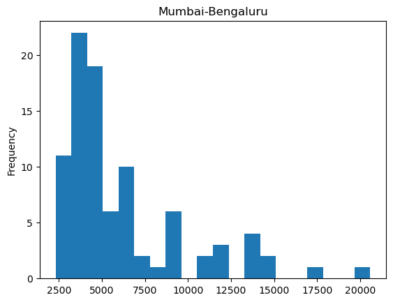

```python
plt.title("Mumbai-Bengaluru")
df_1["Price"].plot(kind = "hist",bins = 20)
plt.show()
```

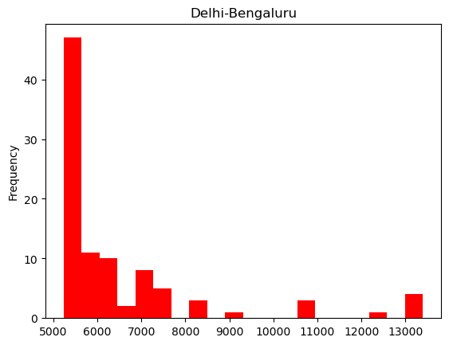

```python
plt.title("Delhi-Bengaluru")
df_2["Price"].plot(kind = "hist",bins = 20 , color = "Red")
plt.show()
```

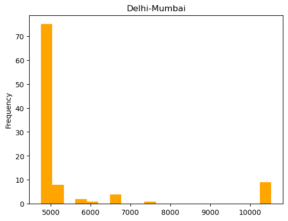

```python
plt.title("Delhi-Mumbai")
df_3["Price"].plot(kind = "hist",bins = 20 , color = "orange")
plt.show()
```

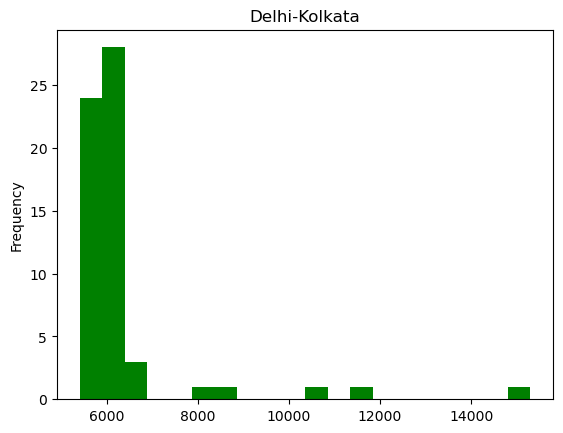

```python
plt.title("Delhi-Kolkata")
df_4["Price"].plot(kind = "hist",bins = 20 , color = "green")
plt.show()
```

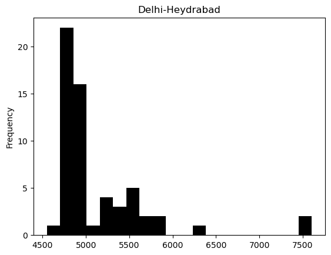

```python
plt.title("Delhi-Heydrabad")
df_5["Price"].plot(kind = "hist",bins = 20 , color = "black")
plt.show()
```

as we can see most of the pricing between 2000-9000

Departing Hour Vs Price

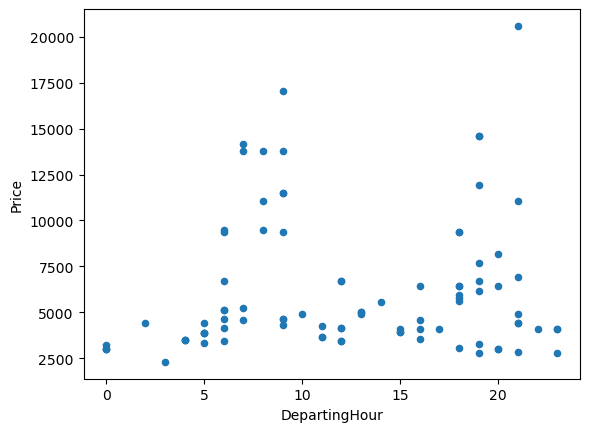

```python
df_1.plot.scatter(x = 'DepartingHour' , y ='Price')
```

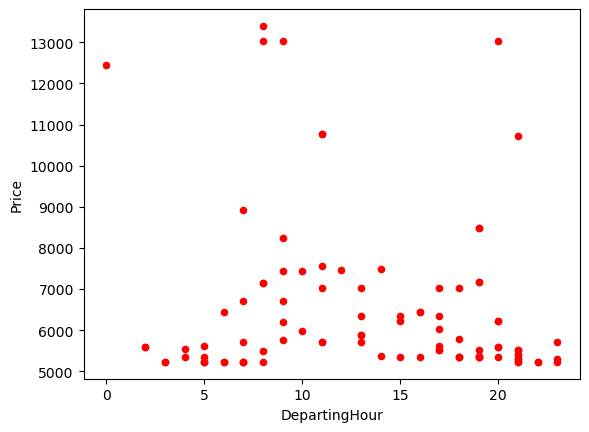

```python
df_2.plot.scatter(x = 'DepartingHour' , y ='Price',color = "Red")
```

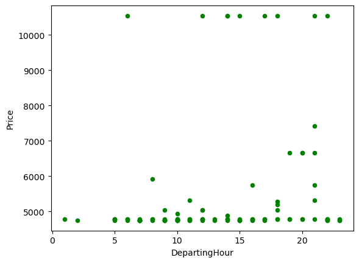

```python
df_3.plot.scatter(x = 'DepartingHour' , y ='Price' , color = "green")
```

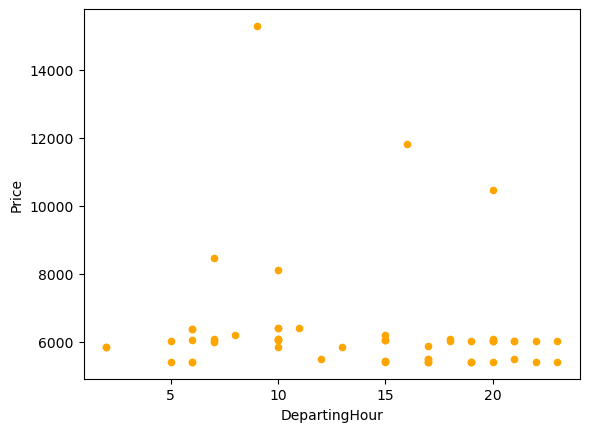

```python
df_4.plot.scatter(x = 'DepartingHour' , y ='Price' , color = "Orange")
```

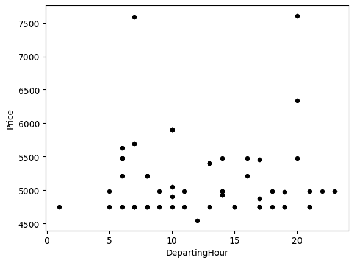

```python
df_5.plot.scatter(x = 'DepartingHour' , y ='Price' , color = "black")
```

# Mumbai(BOM) ↔️ Bengaluru(BLR)

Flights in route

```
array([<Axes: >], dtype=object)
```

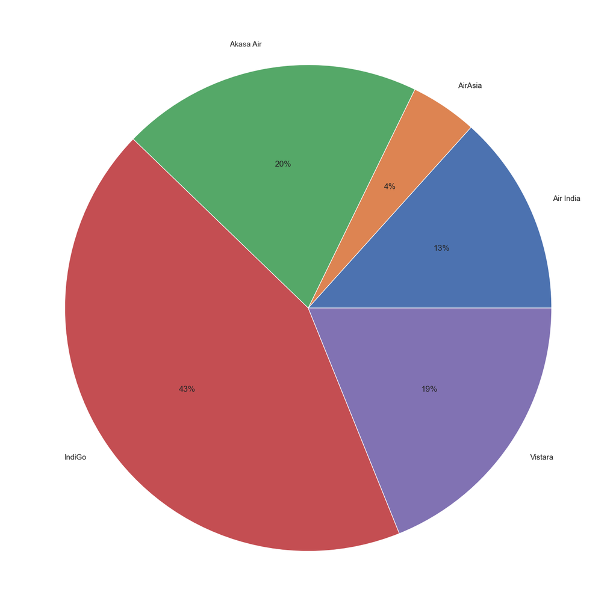

```python
df_1.groupby("FlightName").size().plot(kind='pie',autopct='%1.0f%%',subplots=True)
```

Average Price per flight in route

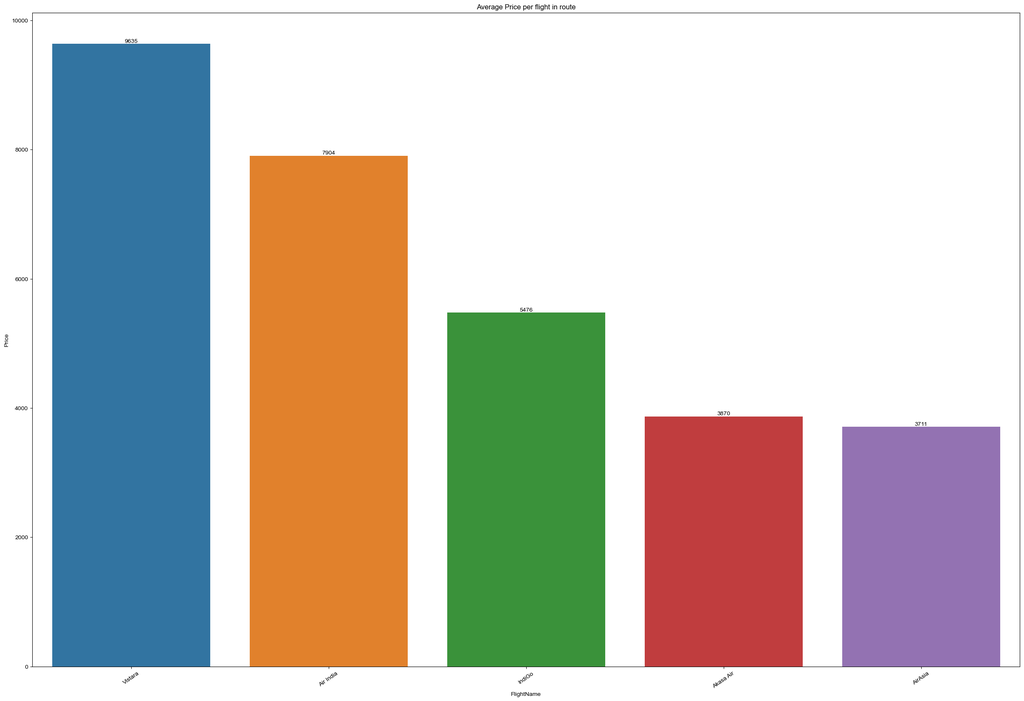

```python
matplotlib.rcParams['figure.figsize'] = (30,20)
df_1_avg_price = df_1.groupby('FlightName')['Price'].mean().reset_index().astype({'Price':'int'}).sort_values(by='Price',ascending=False)
p = sns.barplot(x='FlightName',y='Price',data=df_1_avg_price)
p.bar_label(p.containers[0])
plt.title("Average Price per flight in route")
p.set_xticklabels(labels=df_1_avg_price["FlightName"], rotation=35)
sns.set(font_scale=1.25)
plt.show()
```

DepartingHour Vs Price

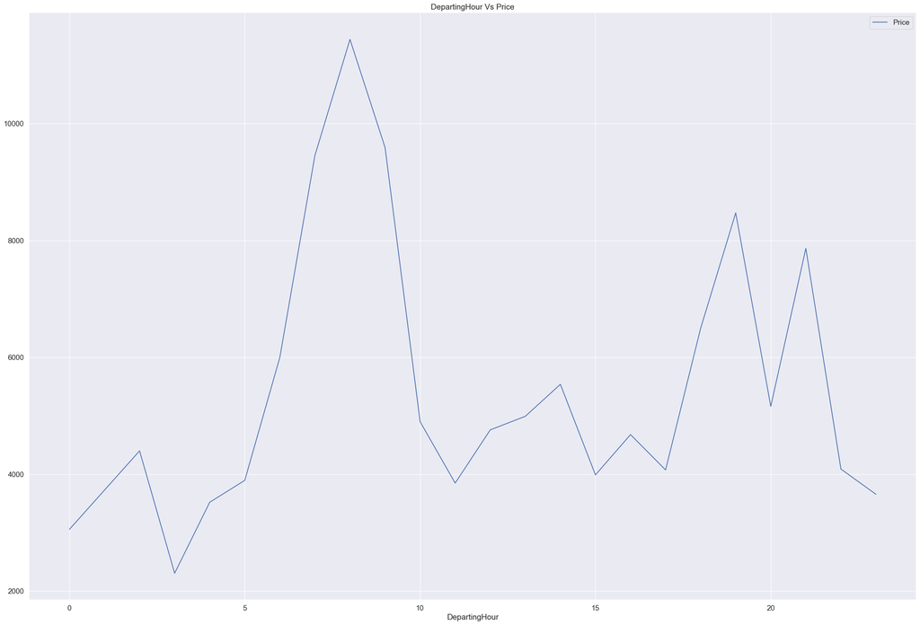

```python
df_dh_avg = df_1.groupby('DepartingHour')['Price'].mean().reset_index()
df_dh_avg.plot.line(x='DepartingHour',y='Price',title='DepartingHour Vs Price')
plt.show()
```

# Delhi(DEL) ↔️ Bengaluru(BLR)

Flights in route

```
array([<Axes: >], dtype=object)
```

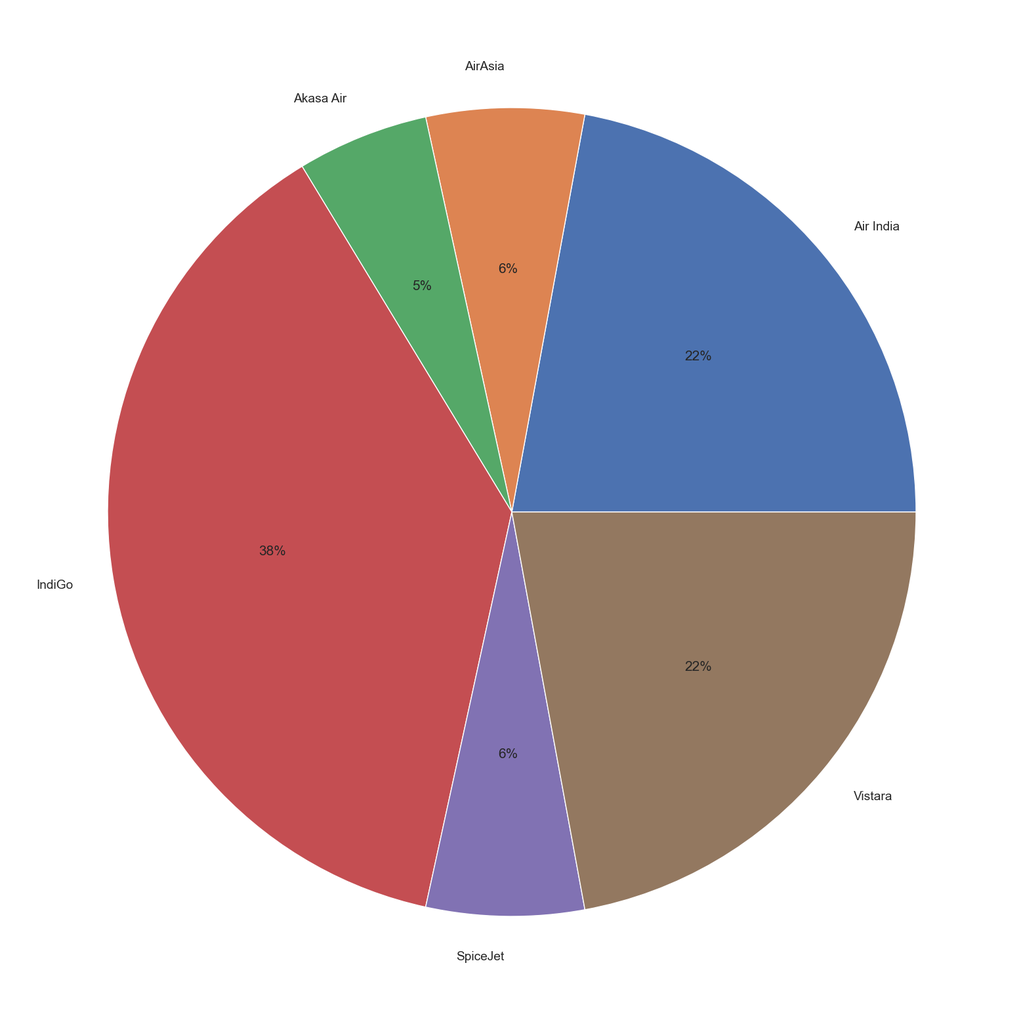

```python
df_2.groupby("FlightName").size().plot(kind='pie',autopct='%1.0f%%',subplots=True)
```

Average Price per flight in route

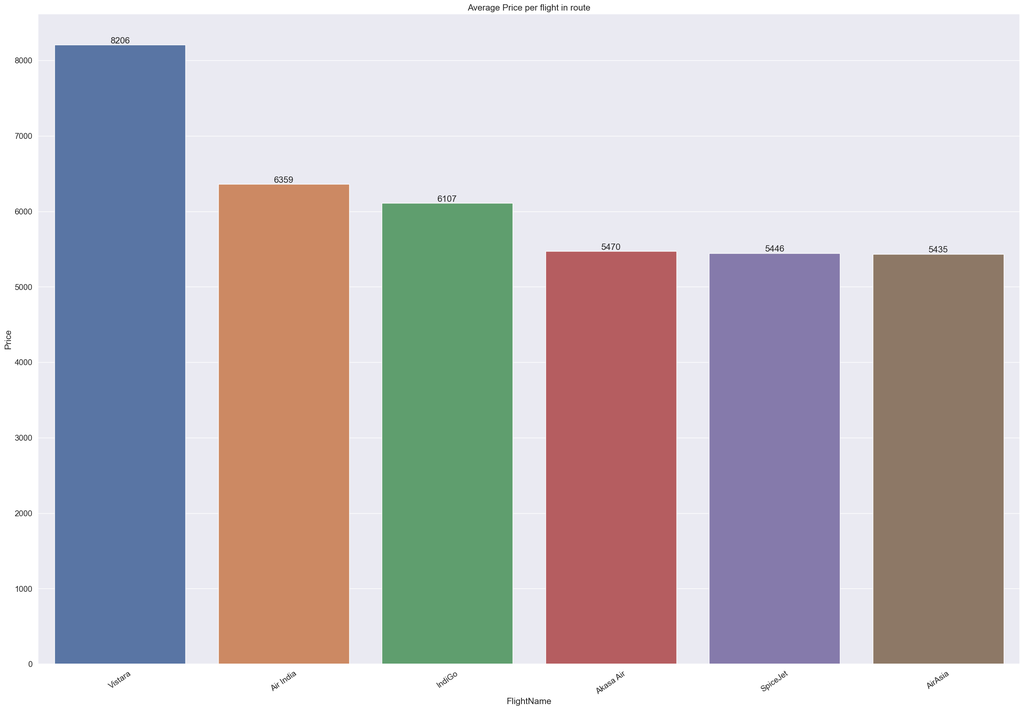

```python
matplotlib.rcParams['figure.figsize'] = (30,20)
df_2_avg_price = df_2.groupby('FlightName')['Price'].mean().reset_index().astype({'Price':'int'}).sort_values(by='Price',ascending=False)
p = sns.barplot(x='FlightName',y='Price',data=df_2_avg_price)
p.bar_label(p.containers[0])
plt.title("Average Price per flight in route")
p.set_xticklabels(labels=df_2_avg_price["FlightName"], rotation=35)
sns.set(font_scale=1.25)
plt.show()
```

DepartingHour Vs Price

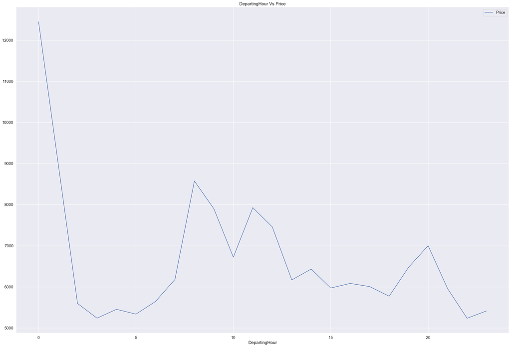

```python
df_dh_avg = df_2.groupby('DepartingHour')['Price'].mean().reset_index()
df_dh_avg.plot.line(x='DepartingHour',y='Price',title='DepartingHour Vs Price')
plt.show()
```

# Delhi(DEL) ↔️ Mumbai(BOM)

Flights in route

```
array([<Axes: >], dtype=object)
```

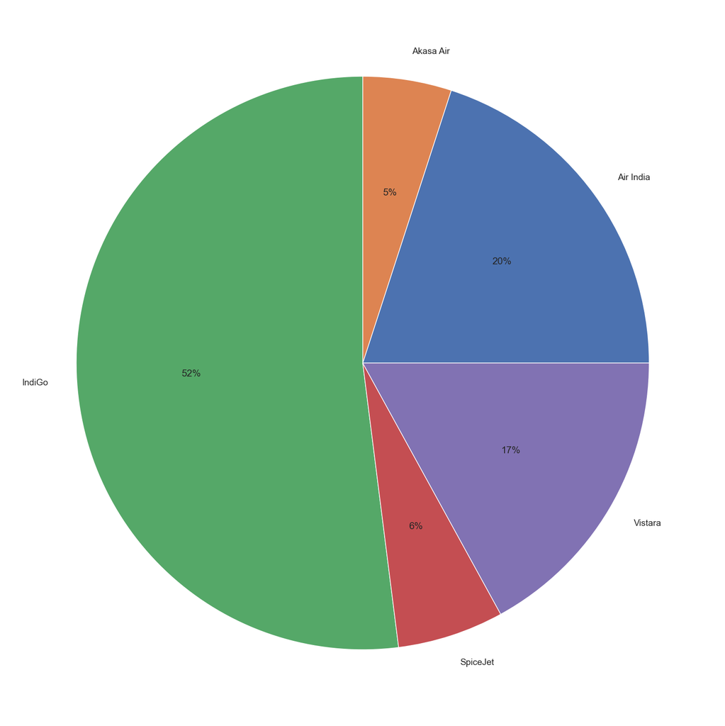

```python
df_3.groupby("FlightName").size().plot(kind='pie',autopct='%1.0f%%',subplots=True)
```

Average Price per flight in route

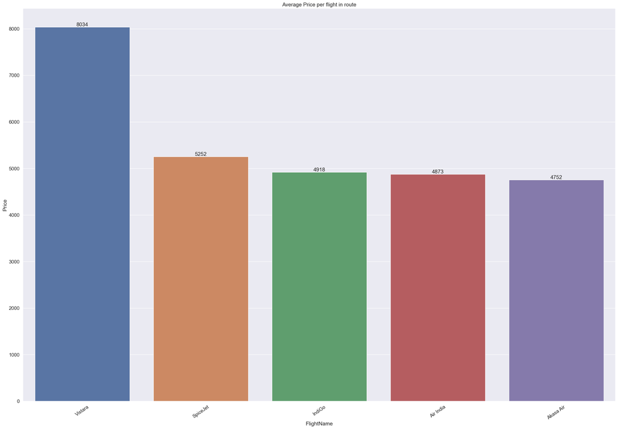

```python
matplotlib.rcParams['figure.figsize'] = (30,20)
df_3_avg_price = df_3.groupby('FlightName')['Price'].mean().reset_index().astype({'Price':'int'}).sort_values(by='Price',ascending=False)
p = sns.barplot(x='FlightName',y='Price',data=df_3_avg_price)
p.bar_label(p.containers[0])
plt.title("Average Price per flight in route")
p.set_xticklabels(labels=df_3_avg_price["FlightName"], rotation=35)
sns.set(font_scale=1.25)
plt.show()
```

DepartingHour Vs Price

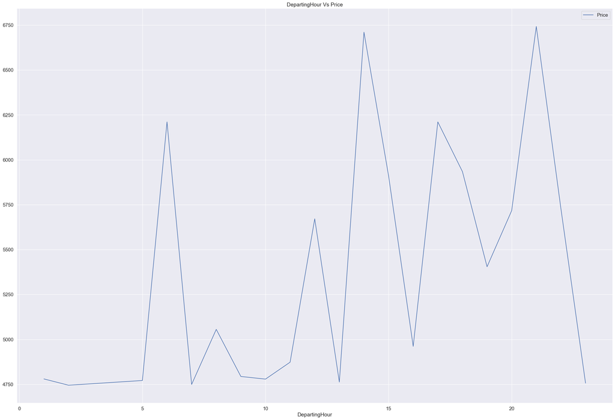

```python
df_dh_avg = df_3.groupby('DepartingHour')['Price'].mean().reset_index()
df_dh_avg.plot.line(x='DepartingHour',y='Price',title='DepartingHour Vs Price')
plt.show()
```

# Delhi(DEL) ↔️ Kolkata(CCU)

Flights in route

```
array([<Axes: >], dtype=object)
```

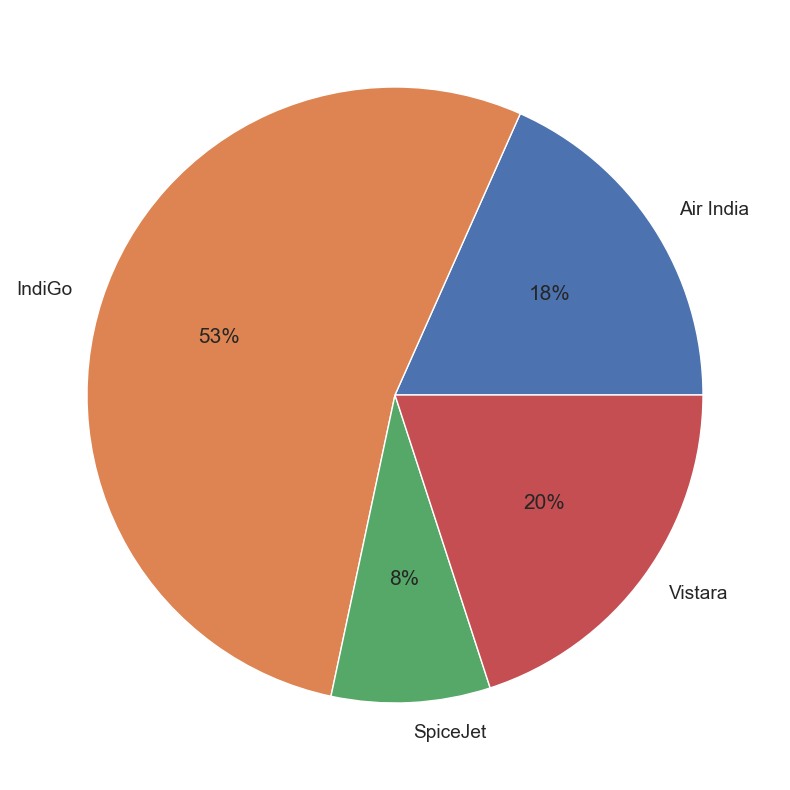

```python
df_4.groupby("FlightName").size().plot(kind='pie',autopct='%1.0f%%',subplots=True)
```

Average Price per flight in route

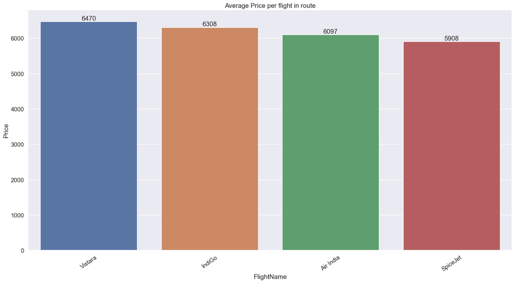

```python
matplotlib.rcParams['figure.figsize'] = (20,10)
df_4_avg_price = df_4.groupby('FlightName')['Price'].mean().reset_index().astype({'Price':'int'}).sort_values(by='Price',ascending=False)
p = sns.barplot(x='FlightName',y='Price',data=df_4_avg_price)
p.bar_label(p.containers[0])
plt.title("Average Price per flight in route")
p.set_xticklabels(labels=df_4_avg_price["FlightName"], rotation=35)
sns.set(font_scale=1.25)
plt.show()
```

DepartingHour Vs Price

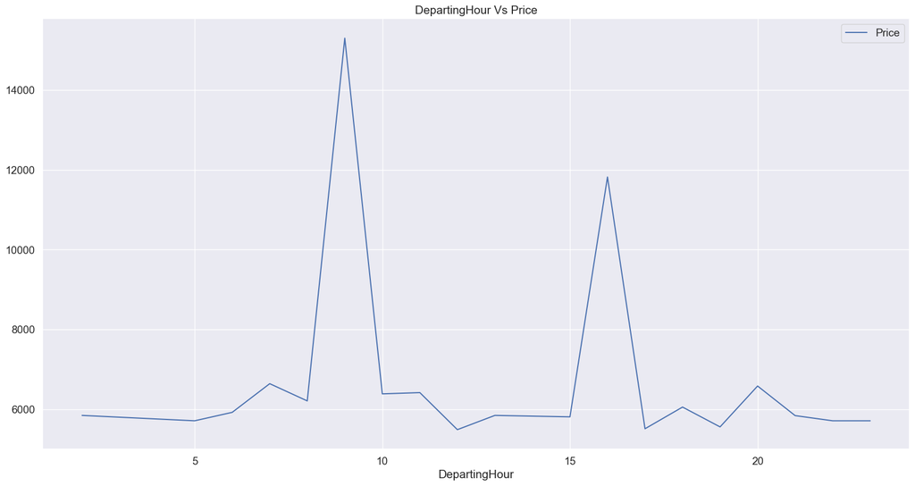

```python
df_dh_avg = df_4.groupby('DepartingHour')['Price'].mean().reset_index()
df_dh_avg.plot.line(x='DepartingHour',y='Price',title='DepartingHour Vs Price')
plt.show()
```

# Delhi(DEL) ↔️ Hyderabad (HYD)

Flights in route

```
array([<Axes: >], dtype=object)
```

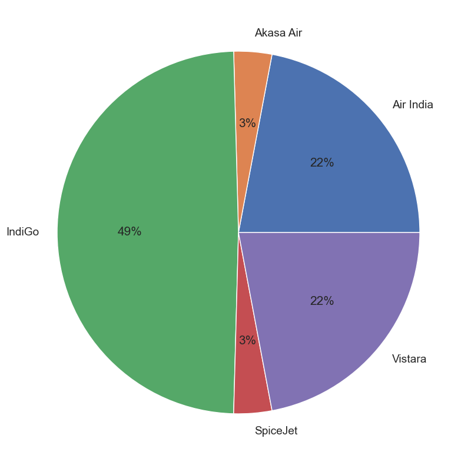

```python
df_5.groupby("FlightName").size().plot(kind='pie',autopct='%1.0f%%',subplots=True)
```

Average Price per flight in route

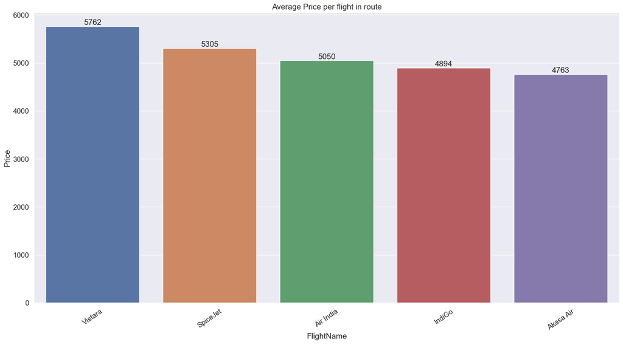

```python
matplotlib.rcParams['figure.figsize'] = (20,10)
df_5_avg_price = df_5.groupby('FlightName')['Price'].mean().reset_index().astype({'Price':'int'}).sort_values(by='Price',ascending=False)
p = sns.barplot(x='FlightName',y='Price',data=df_5_avg_price)
p.bar_label(p.containers[0])
plt.title("Average Price per flight in route")
p.set_xticklabels(labels=df_5_avg_price["FlightName"], rotation=35)
sns.set(font_scale=1.25)
plt.show()
```

DepartingHour Vs Price

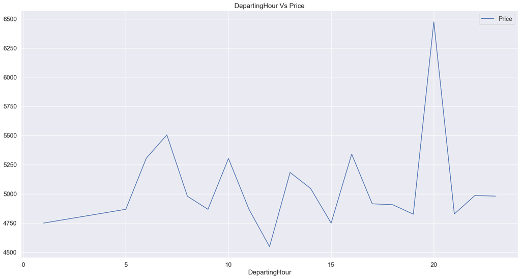

```python
df_dh_avg = df_5.groupby('DepartingHour')['Price'].mean().reset_index()
df_dh_avg.plot.line(x='DepartingHour',y='Price',title='DepartingHour Vs Price')
plt.show()
```